# Kristjánsson et al. (2014): the fitted model

In Kristjánsson, Jóhannesson & Thornton (2014, *PLoS ONE*), people foraged for two types of target on a touch screen, in two conditions: **feature** foraging, where targets differ from distractors in colour alone, and **conjunction** foraging, where they differ in a combination of colour and shape. A well-known result is that in conjunction foraging people tend to collect one target type before switching to the other (long runs), but switch freely in feature foraging.

This page reads the multi-level Fourier-124 fit made by `../fit_models/fit_models.R` (nothing is refitted here; to fit the model yourself, `fit_kristjansson2014plos.R` is the minimal pipeline) and shows how to work with a fitted model: checking convergence, reading the posterior, accuracy and posterior predictive checks. It ends with a model comparison: the full transition matrix against a symmetric one. The fit’s settings are the defaults: the default priors, centred distance and class effects, 4 chains of 1000 warmup and 1000 sampling iterations.

*Note*: the importer rotates this dataset by 180 degrees, so that first selections start top-left as in the other datasets. That orientation is an assumption, so read the absolute-direction results with care.

Code: `kristjansson2014plos.R`.

```r
source("../../../functions/set_up_FoMo.R")
```

```
[1] "set_up_FoMo.R: random seed set to 65 (FOMO_SEED)"
```

```r
source("../fit_models/fit_settings.R")

# the fit this page reads (made by ../fit_models/fit_models.R)
require_example_fits(c("kristjansson2014_fourier124", "kristjansson2014_fourier124_symmetric"))

n_post_draws <- 20   # posterior draws for the posterior predictive check
```

## 1 The data

```r
d <- import_data("kristjansson2014plos")

d$stim |>
  summarise(people = n_distinct(person), trials = n_distinct(trial),
            items_per_trial = n() / n_distinct(trial), .by = condition) |>
  left_join(summarise(d$found, selections = n(), .by = condition), by = "condition") |>
  knitr::kable()
```

| condition | people | trials | items_per_trial | selections |
| --- | --- | --- | --- | --- |
| feature | 16 | 320 | 40 | 12800 |
| conjunction | 16 | 320 | 40 | 12800 |

One random trial from each condition. Items are coloured by target type; the line is the order the targets were selected in.

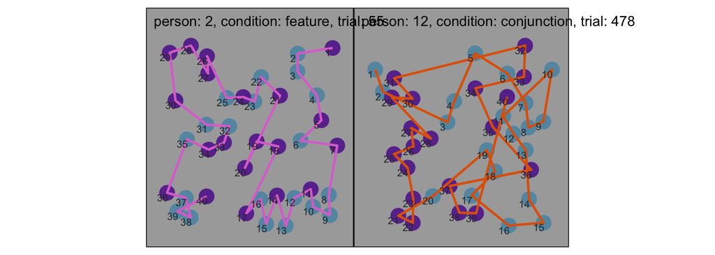

Figure 1: One trial per condition: items and selection order.

```r
plot_trial(d$found, d$stim)
```

How long people kept selecting the same target type before switching (runs): the main difference between the conditions.

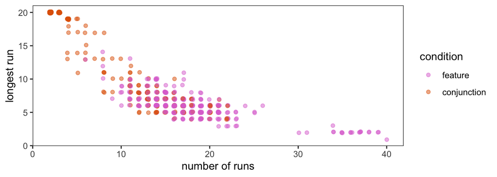

Figure 2: Run lengths by condition.

```r
plot_runs(compute_runs(d$found))
```

Per-trial statistics, used below to check the fitted model against the data.

```r
trial_stats <- compute_trial_stats(d$found)
head(trial_stats) |> knitr::kable(digits = 2)
```

| person | condition | n_found | best_r | mean_itd | pao | n_runs | max_run_length |
| --- | --- | --- | --- | --- | --- | --- | --- |
| 1 | feature | 40 | 0.71 | 0.14 | 14.2 | 17.2 | 6.65 |
| 1 | conjunction | 40 | 0.36 | 0.17 | 47.9 | 3.2 | 18.70 |
| 2 | feature | 40 | 0.76 | 0.15 | 22.8 | 15.8 | 6.60 |
| 2 | conjunction | 40 | 0.32 | 0.18 | 49.5 | 3.3 | 18.95 |
| 3 | feature | 40 | 0.79 | 0.13 | 10.4 | 17.7 | 6.25 |
| 3 | conjunction | 40 | 0.29 | 0.18 | 50.0 | 2.3 | 19.90 |

## 2 The fit

```r
# the fit, and the data list it was made from (fit_fomo() stores it)
fit <- read_example_fit(d, "kristjansson2014", "fourier124")
sl <- attr(fit, "fomo_sl")
```

Population-level estimates (medians and 97% HPDIs) and convergence. R-hat and ESS are coloured green (good), orange (acceptable) or red (bad). At 1000 iterations this fit’s smallest bulk ESS is about 380: fine for medians and intervals, but a published analysis might use 2000.

```r
fomo_summary(fit, cond_labels = levels(d$stim$condition))
```

**Fixed effects (median and 97% HPDI)**

| parameter | condition | component | lower | median | upper | rhat | ess_bulk | ess_tail |
| --- | --- | --- | --- | --- | --- | --- | --- | --- |
| rho_delta | feature |  | 2.29 | 2.59 | 2.89 | 1.00 | 4672 | 2794 |
| rho_delta | conjunction |  | 1.85 | 1.95 | 2.05 | 1.00 | 4185 | 2952 |
| rho_psi | feature |  | -2.57 | -2.18 | -1.73 | 1.00 | 818 | 1355 |
| rho_psi | conjunction |  | -1.67 | -1.44 | -1.20 | 1.00 | 1468 | 2057 |
| fourier_coef | feature | h1 cos | -0.73 | -0.30 | 0.12 | 1.01 | 382 | 725 |
| fourier_coef | conjunction | h1 cos | -0.25 | -0.03 | 0.21 | 1.00 | 548 | 1020 |
| fourier_coef | feature | h1 sin | -0.16 | -0.04 | 0.09 | 1.00 | 942 | 1105 |
| fourier_coef | conjunction | h1 sin | -0.23 | -0.10 | 0.02 | 1.00 | 1109 | 1691 |
| fourier_coef | feature | h2 cos | -0.59 | -0.45 | -0.32 | 1.01 | 661 | 1041 |
| fourier_coef | conjunction | h2 cos | -0.51 | -0.39 | -0.28 | 1.00 | 992 | 1531 |
| fourier_coef | feature | h2 sin | 0.12 | 0.19 | 0.26 | 1.00 | 2111 | 2029 |
| fourier_coef | conjunction | h2 sin | 0.06 | 0.18 | 0.29 | 1.01 | 1046 | 1791 |
| fourier_coef | feature | h4 cos | 0.12 | 0.16 | 0.21 | 1.00 | 3743 | 2719 |
| fourier_coef | conjunction | h4 cos | 0.09 | 0.14 | 0.18 | 1.00 | 4037 | 2917 |
| fourier_coef | feature | h4 sin | -0.10 | -0.04 | 0.01 | 1.00 | 3546 | 2808 |
| fourier_coef | conjunction | h4 sin | -0.05 | -0.01 | 0.03 | 1.00 | 5499 | 3018 |
| b_v | feature | 1,1 | 0.18 | 0.73 | 1.27 | 1.00 | 4301 | 2381 |
| b_v | conjunction | 1,1 | 3.03 | 4.94 | 6.63 | 1.00 | 4400 | 2533 |
| b_v | feature | 2,1 | -1.28 | -0.71 | -0.16 | 1.00 | 5107 | 2223 |
| b_v | conjunction | 2,1 | -4.10 | -2.87 | -1.73 | 1.00 | 4249 | 2617 |

Convergence (all parameters): largest R-hat 1.013 (fourier_coef[1,1]); smallest bulk ESS 382 (fourier_coef[1,1]), tail ESS 713 (sigma_u_fourier_coef[1,4]); 0 divergent transitions.

Rank plots of the five worst-mixing parameters. If the chains have mixed well, each chain’s histogram is roughly flat and they overlap.

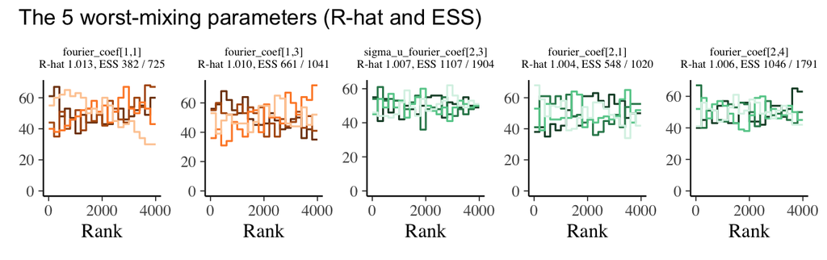

Figure 3: Rank plots of the five worst-mixing parameters, coloured by their R-hat and ESS.

```r
plot_post_traces(fit)
```

## 3 Posterior

`extract_post()` turns the fit’s draws into tidy tables (one per group of parameters), which the `plot_post_*()` functions take.

```r
post <- extract_post(fit, d$found, d$stim)
```

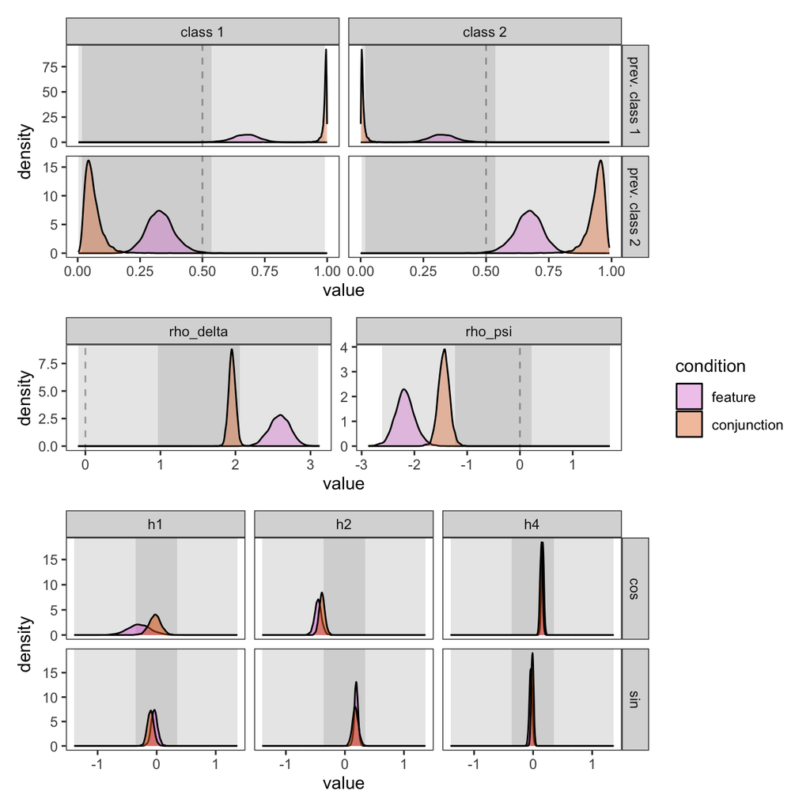

Figure 4: Posterior densities by condition: class transitions, distance and relative direction, and the Fourier coefficients. Grey bands: the priors’ HPDIs.

```r
plot_post(post)
```

The same spatial parameters, shown as what each does to an item’s selection weight:

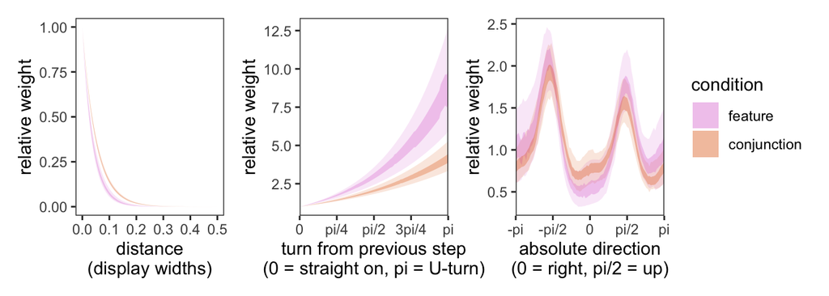

Figure 5: Relative selection weight against distance, turn and absolute direction: 53% and 97% HPDIs.

```r
plot_post_spatial(post, show = "weights")
```

Each person’s distance and relative-direction estimates, over the population’s:

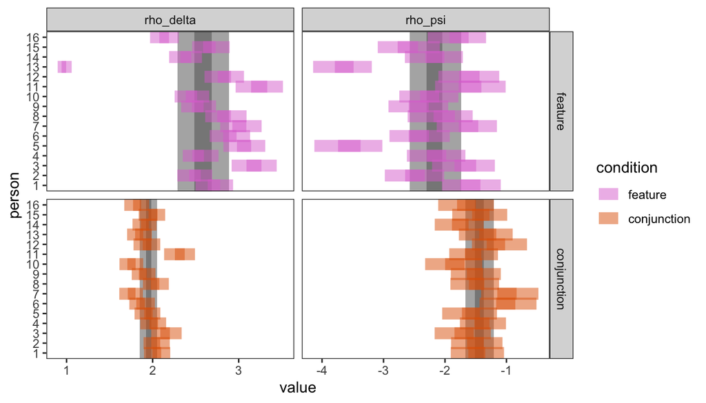

Figure 6: Per-person estimates (intervals) over the population-level HPDIs (grey bands).

```r
plot_post_per_person_spatial(post)
```

And each person’s class-transition probabilities: how likely they are to select each target type next, given the type they just selected. With two types each row of the matrix sums to one, so the columns come in mirrored pairs.

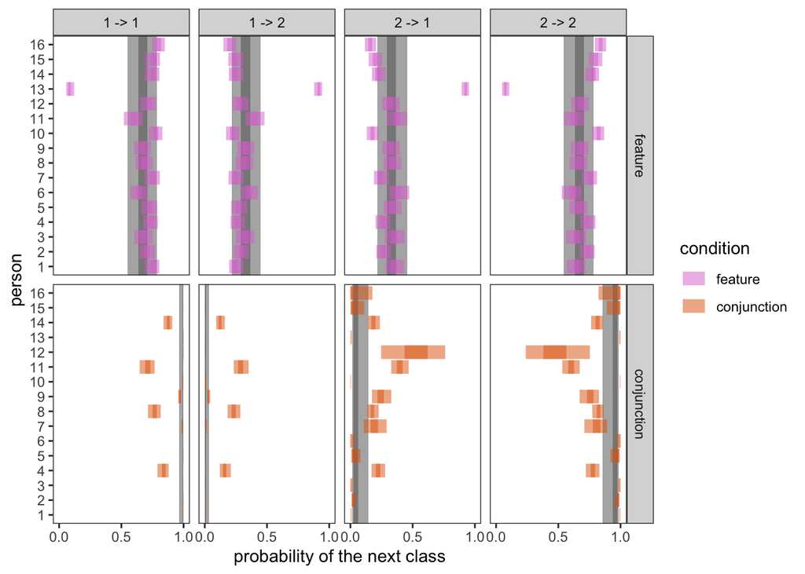

Figure 7: Per-person class-transition probabilities (previous type -> next type) over the population-level HPDIs (grey bands).

```r
plot_post_per_person_cat(post)
```

## 4 Accuracy

The fit doesn’t store a prediction for every selection (`save_selections = FALSE`, the default), so `predict_fomo()` makes them from 200 posterior draws. Deterministic accuracy is how often the item the model judges most likely is the one selected; the probability of the chosen item credits being nearly right too. Chance (dotted) is 1 / items left; the nearest-neighbour rule (dashed) always picks the closest item, so the gap above it is what the model adds to proximity alone. This is in-sample accuracy, which overestimates out-of-sample accuracy.

```r
# the fit doesn't store per-selection predictions (save_selections =
# FALSE), so predict them for a subset of draws
pred <- predict_fomo(fit, sl, n_draws = 200)
acc <- extract_post(pred, d$found, d$stim)$acc
```

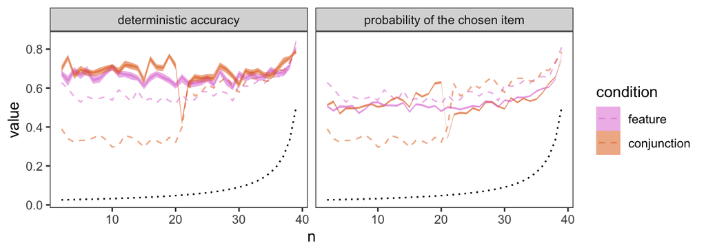

Figure 8: Accuracy at each selection, with chance and nearest-neighbour baselines.

```r
plot_post_accuracy(acc, d$stim, d$found)
```

## 5 Posterior predictive check

Whole trials simulated from the fitted model, compared with the data. The model doesn’t predict when a trial stops, so each simulated trial keeps as many selections as the observed one.

```r
# whole trials simulated from the fit; the model doesn't predict when a
# trial stops, so keep as many simulated selections as the data have
p <- sim_fomo(sl, fit, iter = n_post_draws)
extract_pred(p, d$stim) |>
  semi_join(d$found, by = c("trial", "n")) -> p2
```

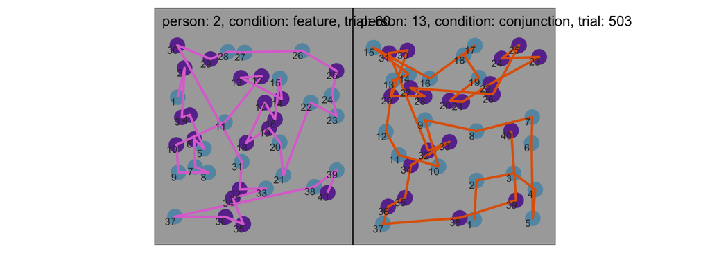

Figure 9: One trial per condition, simulated from the fitted model.

```r
plot_trial(p2, d$stim)
```

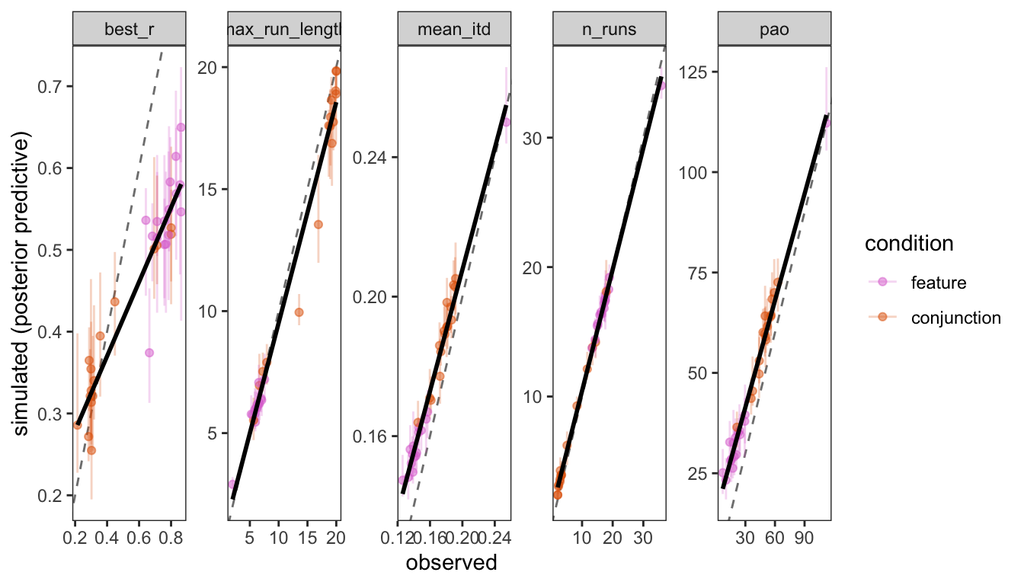

Figure 10: Trial statistics for the data (x) and simulated from the posterior (y). Points near the diagonal mean the model reproduces them.

```r
sim_stats <- compute_trial_stats(p2)
plot_trial_stats(trial_stats, sim_stats)
```

## 6 Model comparison: Symmetric transition matrix?

The model above gives each condition a full 2 x 2 transition matrix: the probability of staying with a target type can differ between the two types, so one type can be preferred overall. A simpler model has one parameter per condition, the probability of staying with the type just selected, the same for both types (`prep_stan_list(symmetric_v = TRUE)`, `cat_sym.stan`): the matrix is symmetric and neither type is preferred. Everything else is the same, and so are the fit’s settings. The comparison asks whether the asymmetry earns its extra parameters.

```r
# the same data fitted with a symmetric transition matrix: one stay
# probability per condition, every other class equally likely
# (prep_stan_list(symmetric_v = TRUE); made by
# ../fit_models/fit_models.R with FOMO_QUEUE=examples)
fit_sym <- read_example_fit(d, "kristjansson2014", "fourier124_symmetric")
fits <- list(full = fit, symmetric = fit_sym)
# loo for each fit, from the per-trial log-likelihoods the fits store
loos <- map(fits, \(f) f$loo())
```

`fomo_compare()` tabulates accuracy (against the nearest-neighbour rule) and loo: `elpd_diff` is the difference from the best model, `se_diff` its standard error, and `robust` whether the difference survives dropping the trials with unreliable (high Pareto k) loo estimates.

```r
cmp <- fomo_compare(fits, d, loos = loos)
format_compare(cmp, columns = c("model", "deterministic", "nn", "gain_nn", "elpd", "elpd_diff",
                                "se_diff", "pct_high_k", "robust"))
```

| model | deterministic | nn | gain_nn | elpd | elpd_diff | se_diff | pct_high_k | robust |
| --- | --- | --- | --- | --- | --- | --- | --- | --- |
| full | 0.674 | 0.533 | 0.141 | -26692 | 0 | 0.0 | 1.4 | TRUE |
| symmetric | 0.673 | 0.533 | 0.141 | -26933 | -242 | 44.1 | 0.9 | TRUE |

The full matrix is clearly better: about 241 elpd ahead (SE 44), with few trials of unreliable loo (about 1%), so the difference is robust. The plot below shows where it comes from. In **feature** search the symmetric model does as well, slightly better even (8 ± 5 elpd, within 2 SE): people stay with the type just selected about two-thirds of the time (stay log-odds 0.72, a probability of about 0.67), and the two types are treated alike. All of the full model’s advantage is in **conjunction** search (250 ± 43): there people almost always stay with the type just selected, but more so for one type than the other: in the full model the stay log-odds are about 4.9 for type 1 and 2.9 for type 2 (probabilities about 0.99 and 0.95; in feature search 0.73 and 0.71, alike). Leaving one type is rarer than leaving the other, which one stay probability for both can’t capture. So the asymmetry is needed, but only for conjunction foraging.

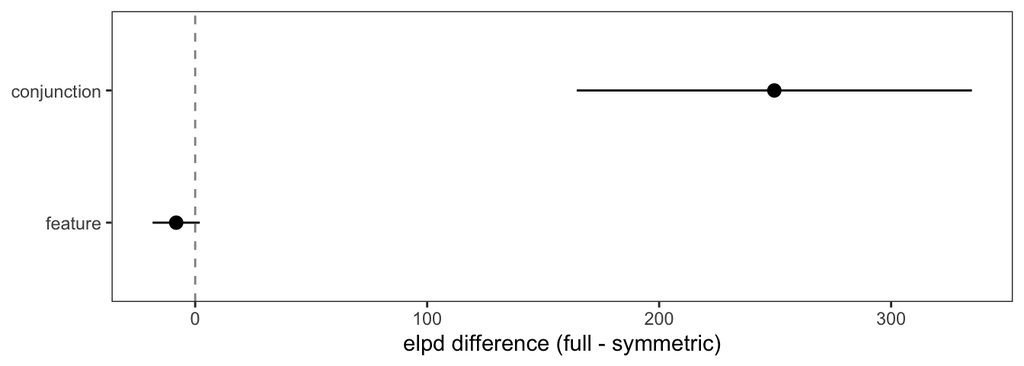

Figure 11: Difference in loo between the full and symmetric models, summed over each condition’s trials (point: sum; bars: 2 SE).

```r
# where the difference comes from: the loo difference summed over each
# condition's trials
plot_post_elpd_by_condition(loos, d$stim)
```